# Exploratory data analysis and graphics: lab 2

Adapted from Ben Bolker 2005

This lab will cover many if not all of the details you actually need to know about R to read in data and produce various figures.

## Packages

To use an additional package it must be (i) installed on your machine (with `install.packages())` or through the menu system and (ii) loaded in your current R session (with `library()`).

```r
# install.packages("plotrix")
library(plotrix)
```

You must both install and load a package before you can use or get help on its functions, although help.search() will list functions in packages that are installed but not yet loaded.

## Reading data

Find the file called seedpred.dat: it’s in the right format (plain text, long format), so you can just read it in with

```r
 df = read.table("Data/seedpred.dat", header = TRUE)
```

Add the variable available to the data frame by combining taken and remaining (using the $ symbol):

```r
 df$available = df$taken + df$remaining
```

## Pitfall #1: finding your file

If R responds to your `read.table()` or `read.csv()` command with an error like

```
Error in file(file, "r") : unable to open connection
In addition: Warning message: cannot open file 'myfile.csv'
```

it means it can’t find your file, probably because it isn’t looking in the right place. By default, R’s working directory is the directory in which the R program starts up, which is (again by default) something like C:/Program Files/R/rw2010/bin. ( R uses / as the [operating-system-independent] separator between directories in a file path.)

You can also use the `setwd()` command to set the working directory (`getwd()` tells you what the current working directory is). While you could just throw everything on your desktop, it’s good to get in the habit of setting up a separate working directory for different projects, so that your data files, metadata files, R script files, and so forth, are all in the same place.

## Reading data

Depending on how you have gotten your data files onto your system (e.g. by downloading them from the web), Windows will sometimes hide or otherwise screw up the extension of your file (e.g. adding .txt to a file called mydata.dat). R needs to know the full name of the file, including the extension.

**Also remember that RMarkdown and R use different default working directories** and even running RMarkdown line by line is different than knitting an entire document or running individual chunks.

## Pitfall #2: checking number of fields

The next potential problem is that R needs every line of your data file to have the same number of fields (variables). You may get an error like:

```
Error in read.table(file = file, header = header, sep = sep, quote = quote,  :
        more columns than column names
```

```
Error in scan(file = file, what = what, sep = sep, quote = quote, dec = dec,  :
        line 1 did not have 5 elements
```

## Pitfall #2: checking number of fields

If you need to check on the number of fields that R thinks you have on each line, use `count.fields("myfile.dat", sep = ",")`

(you can omit the sep=“,” argument if you have whitespace- rather than comma-delimited data). If you are checking a long data file you can try

```
cf = count.fields("myfile.dat", sep = ",")
which(cf != cf[1])
```

to get the line numbers with numbers of fields different from the first line.

## Pitfall #2: checking number of fields

By default R will try to fill in what it sees as missing fields with NA (“not available”) values; this can be useful but can also hide errors. You can try

```
 mydata <- read.csv("myfile.dat", fill = FALSE)
```

to turn off this behavior; if you don’t have any missing fields at the end of lines in your data this should work.

## Checking data

Here’s the quickest way to check that all your variables have been classified correctly:

```
sapply(data, class)
```

```
   Species      tcum      tint remaining     taken available
 "factor" "integer" "integer" "integer" "integer" "integer"
```

(this applies the `class()` command, which identifies the type of a variable, to each column in your data).

## Checking data

Non-numeric missing-variable strings (such as a star, *) will also make R misclassify. Use na.strings in your `read.table()` command:

```
mydata <- read.table("mydata.dat", na.strings = "*")
```

(you can specify more than one value with (e.g.) `na.strings=c("*","***","bad","-9999")`).

## Exercise 1:

Try out head(), summary() and str() on data; make sure you understand the results.

## 1.2 Reshaping data

It’s hard to give an example of reshaping the seed predation data set because we have different numbers of observations for each species - thus, the data won’t fit nicely into a rectangular format with (say) all observations from each species on the same line. However, as in the chapter text I can just make up a data frame and reshape it.

Here are the commands to generate the data frame I used as an example in the text (I use LETTERS, a built-in vector of the capitalized letters of the alphabet, and `runif()`, which picks a specified number of random numbers from a uniform distribution between 0 and 1. The command `round(x,3)` rounds x to 3 digits after the decimal place.):

```r
loc = factor(rep(LETTERS[1:3], 2))
day = factor(rep(1:2, each = 3))
val = round(runif(6), 3)
d = data.frame(loc, day, val)
```

## 1.2 Reshaping data

This data set is in long format. To go to wide format:

```r
d2 = reshape(d, direction = "wide", idvar = "loc", timevar = "day")
d2
```

```
##   loc val.1 val.2
## 1   A 0.504 0.159
## 2   B 0.913 0.989
## 3   C 0.462 0.315
```

`idvar="loc"` specifies that loc is the identifier that should be used to assign multiple values to the same row, and `timevar="day"` specifies which variable can be lumped together on the same row.

## 1.2 Reshaping data

To go back to long format:

```r
reshape(d2, direction = "long", varying = c("val.1", "val.2"), timevar = "day", idvar = "loc")
```

```
##     loc day   val
## A.1   A   1 0.504
## B.1   B   1 0.913
## C.1   C   1 0.462
## A.2   A   2 0.159
## B.2   B   2 0.989
## C.2   C   2 0.315
```

varying specifies which variables are changing and need to be reshaped, and timevar specifies the name of the variable to be (re)created to distinguish different samples in the same location.

## Exercise 2:

`unstack()` works with a formula. Try `unstack(d,val~day)` and `unstack(d,val~loc)` and figure out what’s going on.

The package `tidyr` can also be used to reshape and organize data. Install and load the `tidyr` package. Look up the help menu for the functions `spread()` and `gather()` and try them to go back and forth using the data `d` as we did with reshape.

## 1.3 Advanced data types

While you can usually get by coding data in not quite the right way - for example, coding dates as numeric values or categorical variables as strings - R tries to “do the right thing” with your data, and it is more likely to do the right thing the more it knows about how your data are structured. Strings instead of factors Sometimes R’s default of assigning factors is not what you want: if your strings are unique identifiers (e.g. if you have a code for observations that combines the date and location of sampling, and each location combination is only sampled once on a given date) then R’s strategy of coding unique levels as integers and then associating a label with integers will waste space and add confusion. If all of your non-numeric variables should be treated as character strings rather than factors, you can just specify as.is=TRUE; if you want specific columns to be left “as is” you can specify them by number or column name. For example, these two commands have the same result: > data2 = read.table(“seedpred.dat”, header = TRUE, as.is = “Species”) > data2 = read.table(“seedpred.dat”, header = TRUE, as.is = 1) > sapply(data2, class)

```
 Species        tcum        tint   remaining       taken
```

“character” “integer” “integer” “integer” “integer”

(use c() - e.g. c(“name1”,“name2”) or c(1,3) - to specify more than one column). You can also use the colClasses=“character” argument to read.table() to specify that a particular column should be converted to type character - > data2 = read.table(“seedpred.dat”, header = TRUE, colClasses = c(“character”, + rep(“numeric”, 4)))

again has the same results as the commands above. To convert factors back to strings after you have read them into R, use as.character(). > data2 = read.table(“seedpred.dat”, header = TRUE) > sapply(data2, class)

Species tcum tint remaining taken “factor” “integer” “integer” “integer” “integer”

> data2$Species = as.character(data2$Species) sapply(data2, class)

```
 Species        tcum        tint   remaining       taken
```

“character” “integer” “integer” “integer” “integer”

Factors instead of numeric values In contrast, sometimes you have numeric labels for data that are really categorical values - for example if your sites or species have integer codes (often data sets will have redundant information in them, e.g. both a species name and a species code number). It’s best to specify appropriate data types, so use colClasses to force R to treat the data as a factor. For example, if we wanted to make tcum a factor instead of a numeric variable: > data2 = read.table(“seedpred.dat”, header = TRUE, colClasses = c(rep(“factor”, + 2), rep(“numeric”, 3))) > sapply(data2, class)

Species tcum tint remaining taken “factor” “factor” “numeric” “numeric” “numeric”

n.b.: by default, R sets the order of the factor levels alphabetically. You can find out the levels and their order in a factor f with levels(f). If you want your levels ordered in some other way (e.g. site names in order along some transect), you need to specify this explicitly. Most confusingly, R will sort strings in alphabetic order too, even if they represent numbers. This is OK: > f = factor(1:10) > levels(f)

[1] “1” “2” “3” “4” “5” “6” “7” “8” “9” “10”

but this is not, since we explicitly tell R to treat the numbers as characters (this can happen by accident in some contexts): > f = factor(as.character(1:10)) > levels(f)

[1] “1” “10” “2” “3” “4” “5” “6” “7” “8” “9”

In a list of numbers from 1 to 10, “10” comes after “1” but before “2” … You can fix the levels by using the levels argument in factor() to tell R explicitly what you want it to do, e.g.: > f = factor(as.character(1:10), levels = 1:10) > x = c(“north”, “middle”, “south”) > f = factor(x, levels = c(“far_north”, “north”, “middle”, “south”))

so that the levels come out ordered geographically rather than alphabetically. Sometimes your data contain a subset of integer values in a range, but you want to make sure the levels of the factor you construct include all of the values in the range, not just the ones in your data. Use levels again: > f = factor(c(3, 3, 5, 6, 7, 8, 10), levels = 3:10)

Finally, you may want to get rid of levels that were included in a previous factor but are no longer relevant: > f = factor(c(“a”, “b”, “c”, “d”)) > f2 = f[1:2] > levels(f2)

[1] “a” “b” “c” “d”

> f2 = factor(as.character(f2)) levels(f2)

[1] “a” “b”

For more complicated operations with `factor()`, use the `recode()` function in the `car` (companion for applied regression) package.

## Exercise 3:

Illustrate the effects of the levels command by plotting the factor `f=factor(c(3,3,5,6,7,8,10))` as created with and without intermediate levels.

For an extra challenge, draw them as two side-by-side subplots. (Use `par(mfrow=c(1,1)`) to restore a full plot window.)

## Dates

Dates and times can be tricky in R, but you can (and should) handle your dates as type Date within R rather than messing around with Julian days (i.e., days since the beginning of the year) or maintaining separate variables for day/month/year.

You can use `colClasses="Date"` within `read.table()` to read in dates directly from a file, but only if your dates are in four-digit-year/month/day (e.g. `2005/08/16` or `2005-08-16`) format; otherwise R will either butcher your dates or complain

```
Error in fromchar(x) : character string is not in a standard unambiguous format
```

## Dates

If your dates are in another format in a single column, read them in as character strings (`colClasses="character"` or using `as.is`) and then use `as.Date()`, which uses a very flexible format argument to convert character formats to dates:

```r
 as.Date(c("1jan1960", "2jan1960", "31mar1960", "30jul1960"), format = "%d%b%Y")
```

```
## [1] "1960-01-01" "1960-01-02" "1960-03-31" "1960-07-30"
```

```r
as.Date(c("02/27/92", "02/27/92", "01/14/92", "02/28/92", "02/01/92"), format = "%m/%d/%y")
```

```
## [1] "1992-02-27" "1992-02-27" "1992-01-14" "1992-02-28" "1992-02-01"
```

## Dates

The most useful format codes are `%m` for month number, `%d` for day of month, `%j%` for day of year, `%y%` for two-digit year (dangerous for dates before 1970!) and `%Y%` for four-digit year; see `?strftime` for many more details.

If you have your dates as separate (numeric) day, month, and year columns, you actually have to squash them together into a character format (with `paste()`, using `sep="/"` to specify that the values should be separated by a slash) and then convert them to dates:

```r
year = c(2004, 2004, 2004, 2005)
month = c(10, 11, 12, 1)
day = c(20, 18, 28, 17)
datestr = paste(year, month, day, sep = "/")
date = as.Date(datestr)
date
```

```
## [1] "2004-10-20" "2004-11-18" "2004-12-28" "2005-01-17"
```

## Dates

Although R prints the dates out so they look like a vector of character strings, they are really dates: `class(date)` will give you the answer `"Date"`.

## Dates and Times

Dates and times are always challenging to deal with despite these functions in R. To make life easier Hadley Wickham and others developed the package `lubridate`. I use lubridate almost exclusively now to work with dates in R.

## Exercise: lubridate

Install and load the package `lubridate`. Use it to get today’s date. There is a great tutorial at https://rpubs.com/davoodastaraky/lubridate.

Convert it from year-month-day format to the more familiar US format of month-day-year.

## Other traps:

quotation marks in character variables: if you have character strings in your data set with apostrophes or quotation marks embedded in them, you have to get R to ignore them. I used a data set recently that contained lines like this: Western Canyon|valley|Santa Cruz|313120N|1103145WO’Donnell Canyon

I used

```
 data = read.table("datafile", sep = "|", quote = "")
```

## 1.4 Accessing data and extra packages

Data To access individual variables within your data set use mydata$varname or mydata[,n] or mydata[,"varname"] where n is the column number and varname is the variable name you want. You can also use attach(mydata) to set things up so that you can refer to the variable names alone (e.g. varname rather than mydata$varname). However, beware: if you then modify a variable, you can end up with two copies of it: one (modified) is a local variable called varname, the other (original) is a column in the data frame called varname: it’s probably better not to attach a data set until after you’ve finished cleaning and modifying it. Furthermore, if you have already created a variable called varname, R will find it before it finds the version of varname that is part of your data set. Attaching multiple copies of a data set is a good way to get confused: try to remember to `detach(mydata)` when you’re done.

## Attaching data

I’ll start by attaching the data set (so we can refer to Species instead of data$Species and so on).

```r
attach(df)
```

To access data that are built in to R or included in an R package (which you probably won’t need to do often), say `data(dataset)`

(`data()` by itself will list all available data sets.)

## Exploratory graphics: Bubble plot

Example from http://flowingdata.com/2010/11/23/how-to-make-bubble-charts/

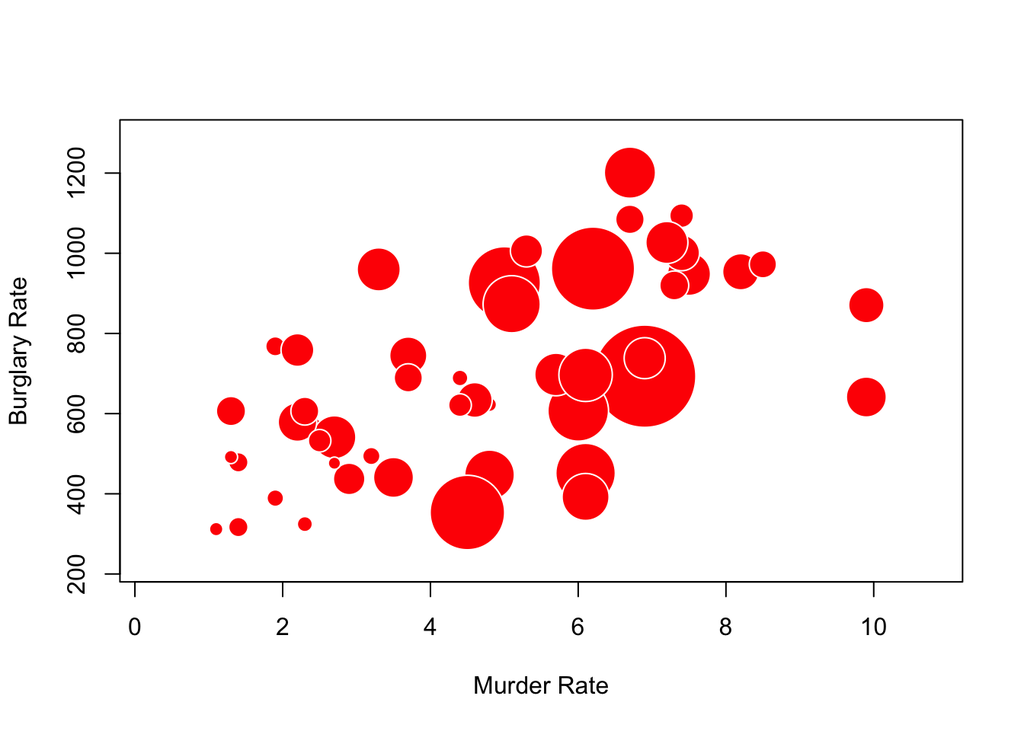

```r
crime <- read.csv("http://datasets.flowingdata.com/crimeRatesByState2005.tsv", header=TRUE, sep="\t")
radius <- sqrt( crime$population/ pi )
symbols(crime$murder, crime$burglary, circles=radius, inches=0.35, fg="white", bg="red", xlab="Murder Rate", ylab="Burglary Rate")
```

## Exploratory graphics

I used

```r
t1 = table(available, taken)
```

## 2.2 Barplot

The command to produce the barplot (Figure 3) was:

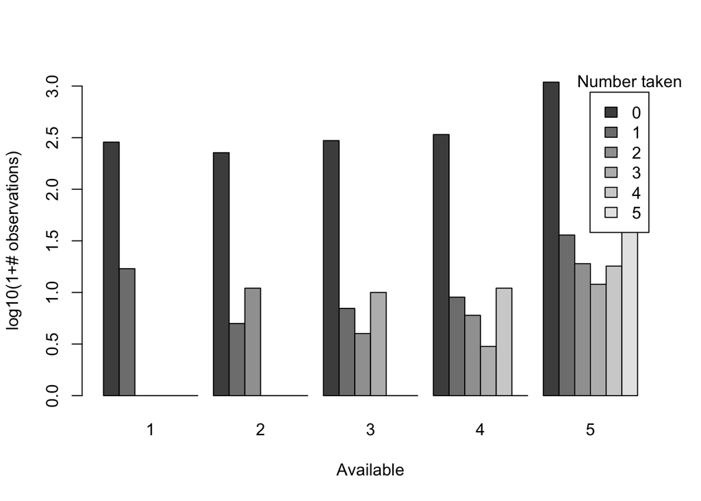

```r
barplot(t(log10(t1 + 1)), beside = TRUE, legend = TRUE, xlab = "Available", ylab = "log10(1+# observations)")
op = par(xpd = TRUE)
text(34.5, 3.05, "Number taken")
```

```r
par(op)
```

As mentioned in the text, log10(t1+1) finds log(x+1), a reasonable transformation to compress the range of discrete data; t() transposes the table so we can plot groups by number available. The beside=TRUE argument plots grouped rather than stacked bars; legend=TRUE plots a legend; and xlab and ylab set labels. The statement par(xpd=TRUE) allows text and lines to be plotted outside the edge of the plot; the op=par(…) and par(op) are a way to set parameters and then restore the original settings (I could have called op anything I wanted, but in this case it stands for old parameters). Exercise 4*: In general, you can specify plotting characters and colors in parallel with your data, so that different points get plotted with different plotting characters and colors. For example: > x = 1:10 > col_vec = rep(1:2, length = 10) > pch_vec = rep(1:2, each = 5) > plot(x, col = col_vec, pch = pch_vec)

More impressively, the lattice package can automatically plot a barplot of a three-way cross-tabulation, in small multiples (I had to experiment a bit to get the factors in the right order in the table() command): try > barchart(log10(1 + table(available, Species, taken)), stack = FALSE, + auto.key = TRUE)

## Exercise 5:

Restricting your analysis to only the observations with 5 seeds available, create a barplot showing the distribution of number of seeds taken broken down by species.

Hints: you can create a new data set that includes only the appropriate rows by using row indexing, then attach() it.

## 2.3 Barplot with error bars

Computing the fraction taken: > frac_taken = taken/available

Computing the mean fraction taken for each number of seeds available, using the tapply() function: tapply() (“table apply”, pronounced “t apply”), is an extension of the table() function; it splits a specified vector into groups according to the factors provided, then applies a function (e.g. mean() or sd()) to each group. This idea of applying a function to a set of objects is a very general, very powerful idea in data manipulation with R; in due course we’ll learn about apply() (apply a function to rows and columns of matrices), lapply() (apply a function to lists), sapply() (apply a function to lists and simplify), and mapply() (apply a function to multiple lists). For the present, though, > mean_frac_by_avail = tapply(frac_taken, available, mean)

computes the mean of frac_taken for each group defined by a different value of available ( R automatically converts available into a factor temporarily for this purpose). If you want to compute the mean by group for more than one variable in a data set, use aggregate(). We can also calculate the standard errors, s/�n: > n_by_avail = table(available) > se_by_avail = tapply(frac_taken, available, sd)/sqrt(n_by_avail)

I’ll actually use a variant of barplot(), barplot2() (from the gplots package, which you may need to install, along with the the gtools and gdata packages) to plot these values with standard errors. (I am mildly embarrassed that R does not supply error-bar plotting as a built-in function, but you can use the barplot2() in the gplots package or the plotCI() function (the gplots and plotrix packages have slightly different versions). > library(gplots) > lower_lim = mean_frac_by_avail - se_by_avail > upper_lim = mean_frac_by_avail + se_by_avail > b = barplot2(mean_frac_by_avail, plot.ci = TRUE, ci.l = lower_lim, + ci.u = upper_lim, xlab = “Number available”, ylab = “Mean number taken”)

I specified that I wanted error bars plotted (plot.ci=TRUE) and the lower (ci.l) and upper (ci.u) limits.

## 2.4 Histograms by species

All I had to do to get the lattice package to plot the histogram by species was: > histogram(~frac_taken | Species, xlab = “Fraction taken”)

It’s possible to do this with base graphics, too, but you have to rearrange your data yourself: essentially, you have to split the data up by species, tell R to break the plotting area up into subplots, and then tell R to draw a histogram in each subplot. To reorganize the data appropriately and draw the plot, I first use split(), which cuts a vector into a list according to the levels of a factor - in this case giving us a list of the fraction-taken data separated by species: > splitdat = split(frac_taken, Species)

Next I use the par() command > op = par(mfrow = c(3, 3), mar = c(2, 2, 1, 1))

to specify a 3 × 3 array of mini-plots (mfrow=c(3,3)) and to reduce the margin spacing to 2 lines on the bottom and left sides and 1 line on the top and right (mar=c(2,2,1,1)). Finally, I combine lapply(), which applies a command to each of the elements in a list, with the hist() (histogram) command. You can specify extra arguments in lapply() that will be passed along to the hist() function - in this case they’re designed to strip out unnecessary detail and make the subplots bigger. > h = lapply(splitdat, hist, xlab = “”, ylab = “”, main = “”, col = “gray”)

Assigning the answer to a variable stops R from printing the results, which I don’t really want to see in this case. par(op) will restore the previous graphics parameters. It’s a bit harder to get the species names plotted on the graphs: it is technically possible to use mapply() to do this, but then we’ve reinvented most of the wheels used in the lattice version … Plots in this section: scatterplot (plot() or xyplot()) bubble plot (sizeplot()), barplot (barplot() or barchart() or barplot2()), histogram (hist() or histogram()). Data manipulation: reshape(), stack()/unstack(), table(), split(), lapply(), sapply()

## 3 Measles data

I’m going to clear the workspace (rm(list=ls()) lists all the objects in the workspace with ls() and then uses rm() to remove them: you can also Clear workspace from the menu) and read in the measles data, which are space-separated and have a header: > detach(df) > rm(list = ls()) > data = read.table(“ewcitmeas.dat”, header = TRUE, na.strings = “*“) > attach(data)

year, mon, and day were read in as integers: I’ll create a date variable as described above. For convenience, I’m also defining a variable with the city names. > date = as.Date(paste(year + 1900, mon, day, sep = “/”)) > city_names = colnames(data)[4:10]

Later on it will be useful to have the data in long format. It’s easiest to do use stack() for this purpose (data.long = stack(data[,4:10])), but that wouldn’t preserve the date information. As mentioned in the chapter, reshape() is trickier but more flexible: > data = cbind(data, date) > data_long = reshape(data, direction = “long”, varying = list(city_names), + v.name = “incidence”, drop = c(“day”, “mon”, “year”), times = factor(city_names), + timevar = “city”)

## 3.1 Multiple-line plots

matplot() (matrix plot), which plots several different numeric variables on a common vertical axis, is most useful when we have a wide format (otherwise it wouldn’t make sense to plot multiple columns on the same scale). I’ll plot columns 4 through 10, which represent the incidence data, against the date, and I’ll tell R to use lines (type=“l”), and to plot all lines in different colors with different line types (the colors aren’t very useful since I have set them to different gray scales for printing purposes, but the example should at least give you the concept). I also have to tell it not to put on any axes, because R won’t automatically plot a date axis. Instead, I’ll use the axis() and axis.Date() commands to add appropriate axes to the left (side=2) and bottom (side=1) sides of the plot, and then use box() to draw a frame around the plot. I’ve used abline() to add vertical lines (v=) to the plot every two years, and also on 1 January 1968 (approximately when mass vaccination against measles began in the UK). You can also use abline() to add horizontal lines (h=); or lines with intercepts (a=) and slopes (b=). (I use seq.Date(), a special command to create a sequence of dates, to define the beginning of biennial periods.) legend() puts a legend on the plot; I set the line width (lwd to 2 so you could actually see the different colors. Here are the commands: > matplot(date, data[, 4:10], type = “l”, col = 1:7, lty = 1:7, + axes = FALSE, ylab = “Weekly incidence”, xlab = “Date”) > axis(side = 2) > axis.Date(side = 1, x = date) > vacc.date = as.Date(“1968/1/1”) > biennial = seq.Date(as.Date(“1948/9/1”), as.Date(“1986/9/1”), + by = “2 years”) > abline(v = biennial, col = “gray”, lty = 2) > abline(v = vacc.date, lty = 2, lwd = 2) > legend(x = 1970, y = 5000, city_names, col = 1:7, lty = 1:7, + lwd = 2, bg = “white”) > box()

I could use the long-format data set and the lattice package to do this more easily, although without the refinements of a date axis, using > xyplot(incidence ~ date, groups = city, data = data_long, type = “l”, + auto.key = TRUE)

To plot each city in its own subplot, use the formula incidence~date|city and omit the groups argument. You can also draw any of these plots with different kinds of symbols (“l” for lines, “p” for points (default): see ?plot for other options).

## 3.2 Histogram and density plots

I’ll start by just collapsing all the incidence data into a single, logged, non-NA vector (in this case I have to use c(as.matrix(x)) to collapse the data and remove all of the data frame information): > allvals = na.omit(c(as.matrix(data[, 4:10]))) > logvals = log10(1 + allvals)

The histogram (hist() command is fairly easy: the only tricks are to leave room for the other lines that will go on the plot by setting the y limits with ylim, and to specify that we want the data plotted as relative frequencies, not numbers of counts (freq=FALSE or prob=TRUE). This option tells R to divide by total number of counts and then by the bin width, so that the area covered by all the bars adds up to 1; this scaling makes the vertical scale of the histogram compatible with a density plot, or among different histograms with different number of counts or bin widths (?? include in chapter ??). > hist(logvals, col = “gray”, main = “”, xlab = “Log weekly incidence”, + ylab = “Density”, freq = FALSE, ylim = c(0, 0.6))

Adding lines for the density is straightforward, since R knows what to do with a density object - in general, the lines command just adds lines to a plot. > lines(density(logvals), lwd = 2) > lines(density(logvals, adjust = 0.5), lwd = 2, lty = 2)

Adding the estimated normal distribution requires a couple of new functions: dnorm() computes the probability density function of the normal distribution with a specified mean and standard deviation (much more on this in Chapter 4). curve() is a magic function for drawing a theoretical curve (or, if add=TRUE, adding one to an existing plot) . The magic part is that your curve must be expressed in terms of x; curve(x^22*x)+ will work, but curve(y^22*y)+ won’t. You can specify other graphics parameters (line type (lty) and width (lwd) in this case). > curve(dnorm(x, mean = mean(logvals), sd = sd(logvals)), lty = 3, + lwd = 2, add = TRUE)

By now the legend() command should be reasonably self-explanatory: > legend(x = 2.1, y = 0.62, legend = c(“density, default”, “density, adjust=0.5”, + “normal”), lwd = 2, lty = c(1, 2, 3))

## 3.3 Scaling data

Scaling the incidence in each city by the population size, or by the mean or maximum incidence in that city, begins to get us into some non-trivial data manipulation. This process may actually be easier in the wide format. Several useful commands: rowMeans(), rowSums(), colMeans(), and colSums() will compute the means or sums of columns efficiently. In this case we would do something like colMeans(data[,4:10]) to get the mean incidence for each city. apply() is the more general command for running some command on each of a set of rows or columns. When you look at the help for apply() you’ll see an argument called MARGIN, which specifies whether you want to operate on rows (1) or columns (2). For example, apply(data[,4:10],1,mean) is the equivalent of rowMeans(data[,4:10]), but we can also easily say (e.g.) apply(data[,4:10],1,max) to get the maxima instead. Later, when you’ve gotten practice defining your own functions, you can apply any function - not just R’s built-in functions. scale() is a function for subtracting and dividing specified amounts out of the columns of a matrix. It is fairly flexible: scale(x,center=TRUE,scale=TRUE) will center by subtracting the means and then scale by dividing by the standard errors of the columns. Fairly obviously, setting either to FALSE will turn off that part of the operation. You can also specify a vector for either center or scale, in which case scale() will subtract or divide the columns by those vectors instead. Exercise 6*: figure out how to use apply() and scale() to scale all columns so they have a minimum of 0 and a maximum of 1 (hint: subtract the minimum and divide by (max-min)). sweep() is more general than scale; it will operate on either rows or columns (depending on the MARGIN argument), and it will use any operator (typically “-”, “/”, etc. - arithmetic symbols must be in quotes) rather than just subtracting or dividing. For example, sweep(x,1,rowSums(x),“/”) will divide the rows (1) of x by their sums.

## Exercise 7:

figure out how to use a call to sweep() to do the same thing as scale(x,center=TRUE,scale=FALSE).

So, if I want to divide each city’s incidence by its mean (allowing for adding 1) and take logs: > logscaledat = as.data.frame(log10(scale(1 + data[, 4:10], center = FALSE, + scale = colMeans(1 + data[, 4:10], na.rm = TRUE))))

You can also scale the data while they are in long format, but you have to think about it differently. Use tapply() to compute the mean incidence in each city, ignoring NA values, and adding 1 to all values: > city_means <- tapply(1 + data_long$incidence, data_long$city, + mean, na.rm = TRUE)

Now you can use vector indexing to scale each incidence value by the appropriate mean value - city_means[data_long$city] does the trick. (Why?) > scdat <- (1 + data_long$incidence)/city_means[data_long$city]

## Exercise 8*:

figure out how to scale the long-format data to minima of zero and maxima of 1.

## Plotting

Here are (approximately) the commands I used to plot the scaled data. First, I ask R to set up the graph by plotting the first column, but without actually putting any lines on the plot (type=“n”): > plot(density(na.omit(logscaledat[, 1])), type = “n”, main = “”, + xlab = “Log scaled incidence”)

Now I do something tricky. I define a temporary function with two arguments - the data and a number specifying the column and line types. This function doesn’t do anything at all until I call it with a specific data vector and number: x and i are just place-holders. > tmpfun = function(x, i) { + lines(density(na.omit(x)), lwd = 2, col = i, lty = i) + }

Now I use the mapply() command (multiple apply) to run the tmpfun() function for all the columns in logscaledat, with different colors and line types. This takes advantage of the fact that I have used as.data.frame() above to make logscaledat back into a data frame, so that its columns can be treated as elements of a list: > m = mapply(tmpfun, logscaledat, 1:7)

Finally, I’ll add a legend. > legend(-2.6, 0.65, city_names, lwd = 2, col = 1:7, lty = 1:7)

Once again, for this relatively simple case, I can get the lattice package to do all of this for me magically: > densityplot(~log10(scdat), groups = data_long$city, plot.points = FALSE, + auto.key = TRUE, lty = 1:7)

(if plot.points=TRUE, as is the default, the plot will include all of the actual data values plotted as points along the zero line - this is often useful but in this case just turns into a blob). However, it’s really useful to know some of the ins and outs for times when lattice won’t do want you want - in those cases it’s often easier to do it yourself with the base package than to figure out how to get lattice to do it. 3.4 Box-and-whisker and violin plots

By this time, box-and-whisker and violin plots will (I hope) seem easy: Since the labels get a little crowded ( R is not really sophisticated about dealing with axis labels - crowded labels just disappear - although you can try the stagger.labs() command from the plotrix package), I’ll use the substr() (substring) command to abbreviate each city’s name to its first three letters. > city_abbr = substr(city_names, 1, 3)

The boxplot() command uses a formula - the variable before the ~ is the data and the variable after it is the factor to use to split the data up. > boxplot(log10(1 + incidence) ~ city, data = data_long, ylab = “Log(incidence+1)”, + names = city_abbr)

Of course, I can do this with the lattice package as well. If I want violin plots instead of boxplots, I specify panel=panel.violin. The scales=list(abbreviate=TRUE) tells the lattice package to make up its own abbreviations (the scale() command is a general-purpose list of options for the subplot formats). > bwplot(log10(1 + incidence) ~ city, data = data_long, panel = panel.violin, + horizontal = FALSE, scales = list(abbreviate = TRUE))

Plots in this section: multiple-groups plot (matplot() or xyplot(…,groups), box-and-whisker plot (boxplot() or bwplot()), density plot (plot(density()) or lines(density()) or densityplot()), violin plot (panel.violin()) Data manipulation: row/colMeans(), row/colSums(), sweep(), scale(), apply(), mapply()

## 4 Continuous data

First let’s make sure the earthquake data are accessible: > data(quakes)

Luckily, most of the plots I drew in this section are fairly automatic. To draw a scatterplot matrix, just use pairs() (base) or splom() (lattice): > pairs(quakes, pch = “.”) > splom(quakes, pch = “.”)

although coplot() has many other options for changing the number of overlapping categories (or shingles the data are divided into; conditioning on more than one variable (use var1*var2 after the vertical bar); colors, line types, etc. etc.. To draw the last figure (various lines plotted against data, I first took a subset of the data with longitude greater than 175: > tmpdat = quakes[quakes$long > 175, ]

Then I generated a basic plot of depth vs. longitude: > plot(tmpdat$long, tmpdat$depth, xlab = “Longitude”, ylab = “Depth”, + col = “darkgray”, pch = “.”)

R knows what to do (plot() or lines) with a lowess() fit. In this case I used the default smoothing parameter (f=2/3), but I could have used a smaller value to get a wigglier line. > lines(lowess(tmpdat$long, tmpdat$depth), lwd = 2)

Adding a line based on a linear regression fit is easy - we did that in Lab 1: > abline(lm(depth ~ long, data = tmpdat), lwd = 2, col = “gray”)

Finally, I do something slightly more complicated - plot the results of a quadratic regression. The regression itself is easy, except that I have to specify longitude-squared as I(long^2) so that R knows I mean to raise longitude to the second power rather than exploring a statistical interaction: > quad.lm = lm(depth ~ long + I(long^2), data = tmpdat)

To calculate predicted depth values across the range of longitudes, I have to set up a longitude vector and then use predict() to generate predictions at these values: > lvec = seq(176, 188, length = 100) > quadvals = predict(quad.lm, newdata = data.frame(long = lvec))

Now I can just use lines() to add these values to the graph, and add a legend: > lines(lvec, quadvals, lwd = 2, lty = 2, col = “gray”) > legend(183.2, 690, c(“lowess”, “spline (default)”, “spline (df=4)”, + “regression”, “quad. regression”), lwd = 2, lty = c(1, 2, + 3, 1, 2), col = c(rep(“black”, 3), rep(“gray”, 2)))

Plots in this section: scatterplot matrix (pairs(), splom()), conditioning plot (coplot()), spline (smooth.spline() and locally weighted (lowess()) smoothing

## Exercise 9*:

generate three new plots based on one of the data sets in this lab, or on your own data.

File translated from TEX by TTH, version 3.67. On 12 Sep 2005, 12:35.